# 03_Link_DataPop_Models_v2

Implementação final

Tese de Doutorado

Carlos Eduardo Beluzo

Jun 2024

# Imporatção de Libs e Preparação de Dados

#### pip install

```python
!pip install imblearn xgboost yellowbrick shap
```

#### imports

```python
import pandas as pd
import matplotlib.pyplot as plt
import seaborn as sns
import os
from datetime import datetime
import numpy as np
import pickle

# Preprocessing
from sklearn.preprocessing import StandardScaler, MinMaxScaler
from imblearn.under_sampling import EditedNearestNeighbours
from imblearn.over_sampling import ADASYN

# ML
from sklearn.model_selection import train_test_split
from sklearn.linear_model import LogisticRegression, LogisticRegressionCV, SGDOneClassSVM
from sklearn.naive_bayes import ComplementNB, CategoricalNB, MultinomialNB
import xgboost as xgb
from sklearn.svm import OneClassSVM
from sklearn.ensemble import IsolationForest

# Metrics
from sklearn.metrics import accuracy_score, confusion_matrix, roc_curve, auc, classification_report, roc_auc_score
from sklearn.metrics import precision_recall_curve, precision_score, recall_score, f1_score, ConfusionMatrixDisplay
import shap
from sklearn.inspection import permutation_importance
from yellowbrick.classifier import PrecisionRecallCurve

from sklearn.feature_selection import SelectFromModel
from sklearn.ensemble import VotingClassifier

scaler = MinMaxScaler()
folder = '/content/drive/MyDrive/datasets/Link_DataPop_Coorte_2014/'
folder = 'data/'

final_report = pd.DataFrame()

models = []

pd.set_option('display.max_columns', None)
```

#### def run_experiment

Executa um experimento de classificação utilizando um classificador dado.

```python
def run_experiment(titulo, clf, X_train, y_train, X_test, y_test, X_val, y_val, final_report):
    """
    Executa um experimento de classificação utilizando um classificador dado.

    Args:
    - titulo (str): Título do experimento.
    - clf (classificador): Classificador a ser avaliado.
    - X_train (array-like): Conjunto de treinamento.
    - y_train (array-like): Rótulos do conjunto de treinamento.
    - X_test (array-like): Conjunto de teste.
    - y_test (array-like): Rótulos do conjunto de teste.
    - X_val (array-like): Conjunto de validação.
    - y_val (array-like): Rótulos do conjunto de validação.
    - final_report (DataFrame): DataFrame para armazenar os resultados do experimento.

    Returns:
    - final_report (DataFrame): DataFrame atualizado com os resultados do experimento.
    - clf (classificador): O classificador treinado.
    """

    clf.fit(X_train, y_train)
    y_pred_test = clf.predict(X_test)
    y_pred_val = clf.predict(X_val)

    if type(clf).__name__ in ['IsolationForest','SGDOneClassSVM', 'OneClassSVM']:
        y_pred_test = [1 if i==-1 else 0 for i in y_pred_test]
        y_pred_val = [1 if i==-1 else 0 for i in y_pred_val]

    # Resultados de Teste
    test_results = imprime_metricas(X_train, X_test, y_test, y_pred_test, clf=clf, graficos=True, titulo=titulo)
    val_results = imprime_metricas(X_train, X_val, y_val, y_pred_val, clf=clf, graficos=False, titulo=titulo[:4] + 'v: Validação')

    final_report = pd.concat([final_report, test_results, val_results], ignore_index=True)

    return final_report, clf
```

#### imprime_metricas

```python
def imprime_metricas(X_train, X_test, y_test, y_pred, clf=None, graficos=False, titulo='Gráfico'):
  print('-------------------------------------------------------------')
  print(titulo + ' - ' + type(clf).__name__ )
  print('-------------------------------------------------------------')

  # Avalie o desempenho do modelo
  conf_matrix = confusion_matrix(y_test, y_pred)
  roc_auc = roc_auc_score(y_test, y_pred)
  classification_rep = classification_report(y_test, y_pred, zero_division=0, output_dict=True)

  classification_rep = pd.DataFrame(classification_rep).transpose().round(2)
  classification_rep.reset_index(inplace=True)
  experiment_number = [titulo[:5]] * 5

  # Adding new column at the first index
  classification_rep.insert(0, '#', experiment_number)
  classification_rep['support'] = classification_rep['support'].astype(int)
  classification_rep['Descrição'] = titulo

  # Imprima as métricas de avaliação
  print("Relatório de Classificação:")
  print(classification_rep[['index','precision','recall','f1-score','support']])
  print('-------------------------------------------------------------')

  if graficos:
    # Matrix Confusão ---------------------------------------------------------
    plt.figure(figsize=(2, 2))
    sns.heatmap(conf_matrix, annot=True, fmt='d', cmap='Blues', cbar=False, annot_kws={"size": 10})
    plt.title("Matrix de Confusão", fontsize=11)
    plt.xlabel('Valores Preditos', fontsize=10)
    plt.ylabel('Valores Reais', fontsize=10)
    plt.savefig('out/MC-' + titulo + '.pdf', bbox_inches='tight')
    plt.show()
    print('')
    # Curva ROC ----------------------------------------------------------------

    if type(clf).__name__ in ['OneClassSVM','IsolationForest', 'SGDOneClassSVM']:
        anomaly_scores = clf.decision_function(X_test)
        predicted_probabilities = -anomaly_scores
    else:
        predicted_probabilities = clf.predict_proba(X_test)[:, 1]


    fpr, tpr, _ = roc_curve(y_test, predicted_probabilities)
    roc_auc = auc(fpr, tpr)

    plt.figure(figsize=(4, 4))
    plt.plot(fpr, tpr, color='darkorange', lw=1, label=f'ROC curve (AUC = {roc_auc:.2f})')
    plt.plot([0, 1], [0, 1], color='navy', lw=1, linestyle='--')
    plt.xlim([0.0, 1.0])
    plt.ylim([0.0, 1.05])
    plt.xlabel('Taxa de Falsos Positivos',fontsize=11)
    plt.ylabel('Taxa de Verdadeiros Positivos',fontsize=11)
    plt.title('Curva ROC',fontsize=12)
    plt.legend(loc="lower right")
    plt.savefig('out/ROC-' + titulo + '.pdf', bbox_inches='tight')
    plt.show()
    print('')

    # Feature Importance - Top 10 ----------------------------------------------

    if type(clf).__name__ in ['OneClassSVM']:
      return classification_rep

    if type(clf).__name__ in ['LogisticRegression', 'LogisticRegressionCV']:
      coefficients = clf.coef_[0]

    if type(clf).__name__ in ['SGDOneClassSVM']:
      coefficients = np.abs(clf.coef_)

    elif type(clf).__name__ == 'XGBClassifier':
      coefficients = clf.feature_importances_

    elif type(clf).__name__ == 'IsolationForest':
      coefficients = np.mean([tree.tree_.compute_feature_importances(normalize=False) for tree in clf.estimators_], axis=0)

    elif type(clf).__name__ in ['ComplementNB','MultinomialNB']:
      coefficients = np.exp(clf.feature_log_prob_)[1]  # Assuming importances for the positive class

    # Plot
    coefficients = np.abs(coefficients)
    top_indices = np.argsort(coefficients)[::-1][:10]
    top_coefficients = coefficients[top_indices]
    sorted_indices = np.argsort(top_coefficients)[::-1][:10]

    #  Get the top 10 feature names and coefficients, sorted in descending order
    top_feature_names = [feature_names[i] for i in top_indices]

    top_features = np.array(top_feature_names)[sorted_indices]
    top_importances = np.array(top_coefficients)[sorted_indices]

    plt.figure(figsize=(8, 4))
    plt.barh(top_features[::-1], top_importances[::-1], color='skyblue')
    plt.xlabel('Magnitude do Coeficiente',fontsize=11)
    plt.ylabel('Variáveis (Features)',fontsize=11)
    plt.title('Importância de Variáveis (Feature Importance) - Top 10',fontsize=12)
    plt.grid(axis='x', linestyle='--', alpha=0.7)
    plt.tick_params(axis='both', which='major', labelsize=10)
    plt.yticks(fontsize=9)  # Adjust the font size (12 is just an example)
    plt.savefig('out/TOP-' + titulo + '.pdf', bbox_inches='tight')
    plt.show()

    # SHAP --------------------------------------------------------------------
    if type(clf).__name__ in ['##IsolationForest','LogisticRegression','XGBClassifier']:
      explainer = shap.Explainer(clf, X_train)
      shap_values = explainer(X_test)
      shap.summary_plot(shap_values, X_test, feature_names=feature_names, plot_type="violin", max_display=10, show=False)
      plt.title('Explicação de influência de variáveis por SHAP', fontsize=12)
      plt.xlabel('Magnitude de influência', fontsize=11)
      plt.ylabel('Variáveis (Features)', fontsize=11)
      plt.yticks(fontsize=9)  # Adjust the font size (12 is just an example)

      plt.gcf().set_size_inches(10, 4)
      plt.savefig('out/SHAP-' + titulo + '.pdf', bbox_inches='tight')
      plt.show()

  else:
      initial_evaluation(clf, X_test, y_test, y_pred)

  return classification_rep
```

#### def plot_donut_chart

Cria um gráfico de donut para visualizar a distribuição de classes.

```python
def plot_donut_chart(df, title=''):
    """
    Cria um gráfico de donut para visualizar a distribuição de classes.

    Args:
    - df (DataFrame): DataFrame contendo os dados a serem visualizados.
    - title (str): Título opcional para o gráfico.

    Returns:
    - None
    """
    plt.figure(figsize=(5, 3))
    sns.set(style="whitegrid")

    # Calcula a contagem de classes
    class_counts = df['OBITO_NEONATAL'].value_counts()

    # Cria o gráfico de donut com Seaborn
    ax = plt.pie(class_counts, labels=['Sobreviventes', 'Óbitos'], autopct='%1.1f%%',
                 colors=['lightcoral', 'lightgreen'], wedgeprops={'edgecolor': 'gray'}, startangle=90, pctdistance=0.5)

    plt.title('Distribuição entre classes ' + title)

    # Adiciona valores absolutos como legendas
    total_count = len(df)
    abs_values = [f'{count}' for count in class_counts]
    plt.legend(abs_values, title='Totais', loc='center left', bbox_to_anchor=(0.6, 0.25))

    plt.show()
```

#### def initial_evaluation

```python
def initial_evaluation(clf, X_test, y_test, y_pred = None):
    if y_pred is None:
        y_pred = clf.predict(X_test)

    print("Accuracy:", accuracy_score(y_test, y_pred))
    print("Confusion Matrix")
    print(confusion_matrix(y_test, y_pred))

    # Compute ROC curve
    # Assuming y_val contains binary labels (0 and 1) and ensemble_probs contains predicted probabilities for class 1
    try:
        proba = clf.predict_proba(X_test)
        fpr, tpr, thresholds = roc_curve(y_test, proba[:, 1])

        # Compute ROC area under the curve (AUC)
        roc_auc = roc_auc_score(y_test, proba[:, 1])

        # Plot ROC curve
        plt.figure(figsize=(4,4))
        plt.plot(fpr, tpr, color='darkorange', lw=1, label='ROC curve (area = %0.2f)' % roc_auc)
        plt.plot([0, 1], [0, 1], color='navy', lw=1, linestyle='--')
        plt.xlim([0.0, 1.0])
        plt.ylim([0.0, 1.05])
        plt.xlabel('False Positive Rate')
        plt.ylabel('True Positive Rate')
        plt.title('ROC Curve')
        plt.legend(loc="lower right")
        plt.show()
    except:
        None
```

#### plot_weight_distribution

Plota a distribuição de peso em relação à variável alvo 'OBITO_NEONATAL'.

```python
def plot_weight_distribution(X, y, col1, col2):
    """
    Plota a distribuição de peso em relação à variável alvo 'OBITO_NEONATAL'.

    Args:
    - X (DataFrame): DataFrame contendo os recursos.
    - y (Series): Série contendo a variável alvo.
    - col1 (str): Nome da primeira coluna a ser plotada.
    - col2 (str): Nome da segunda coluna a ser plotada.

    Returns:
    - None
    """

    df_aux = X[[col1, col2]].copy()
    df_aux['OBITO_NEONATAL'] = y.copy()

    # Filtra dados válidos e não nulos
    valid_data_vivos = df_aux[(df_aux['OBITO_NEONATAL'] == 0)]
    valid_data_mortos = df_aux[(df_aux['OBITO_NEONATAL'] == 1)]

    fig, axes = plt.subplots(1, 2, figsize=(14, 4))  # Cria subplots com 1 linha e 2 colunas

    # Plot para a distribuição de PESO
    for i, col in enumerate([col1, col2]):

        # Plota o gráfico de densidade (KDE) com o log das colunas
        sns.kdeplot(data=valid_data_vivos, x=np.log(valid_data_vivos[col] + 1e-9), label='Sobreviventes', fill=True, ax=axes[i])
        sns.kdeplot(data=valid_data_mortos, x=np.log(valid_data_mortos[col] + 1e-9), label='Óbitos Neonatais', fill=True, ax=axes[i])

        axes[i].set_xlabel(col)
        axes[i].set_ylabel('Distribuição Densidade (KDE)')
        axes[i].legend()

    plt.tight_layout()  # Ajusta o layout para evitar sobreposição
    plt.show()
```

#### def ensemble_metric

```python
def ensemble_metric(models, model_names, colors, X_test, y_test, title='', final_report=None):
    """
    Evaluate the ensemble of models using ROC and Precision-Recall curves.

    Args:
        models (list): List of trained models.
        model_names (list): List of model names.
        colors (list): List of colors for plotting.
        X_test (array-like): Features of the test set.
        y_test (array-like): Labels of the test set.
        title (str, optional): Title for the ensemble. Defaults to ''.
        final_report (DataFrame, optional): DataFrame to store classification reports. Defaults to None.

    Returns:
        DataFrame: Updated final_report with classification reports.
    """
    predict_array = []
    proba_array = []

    plt.figure(figsize=(7, 7))

    for model, name, color in zip(models, model_names, colors):
        pred = model.predict(X_test)

        if type(model).__name__ in ['IsolationForest', 'SGDOneClassSVM', 'OneClassSVM']:
            # Calculate Proba
            outlier_scores = model.decision_function(X_test)

            # Normalize the scores to the range [0, 1]
            normalized_scores = (outlier_scores - min(outlier_scores)) / (max(outlier_scores) - min(outlier_scores))

            # Invert the scores
            inverted_scores = 1 - normalized_scores

            # Create probability arrays
            probas = np.zeros((len(X_test), 2))
            probas[:, 0] = 1 - inverted_scores
            probas[:, 1] = inverted_scores
            probas = probas
        else:
            probas = model.predict_proba(X_test)

        # Compute ROC curve and AUC
        fpr, tpr, _ = roc_curve(y_test, probas[:, 1])
        roc_auc = auc(fpr, tpr)

        # Plot ROC curve
        plt.plot(fpr, tpr, color=color, lw=1, label='%s (AUC = %0.3f)' % (name, roc_auc))

        predict_array.append(pred)
        proba_array.append(probas)

    # Assuming proba_arrays contains probabilities from each model
    ensemble_probs = np.mean(proba_array, axis=0)

    # Make final predictions
    ensemble_preds_prob = np.argmax(ensemble_probs, axis=1)

    # Evaluate ensemble accuracy
    ensemble_accuracy = accuracy_score(y_test, ensemble_preds_prob)
    print("Ensemble Accuracy:", ensemble_accuracy)

    cm = confusion_matrix(y_test, ensemble_preds_prob)
    print(cm)

    # Calculate classification report for probability averaging ensemble
    ensemble_classification_report_proba = classification_report(y_test, ensemble_preds_prob, zero_division=0,
                                                                   output_dict=True)

    classification_rep = pd.DataFrame(ensemble_classification_report_proba).transpose().round(2)
    classification_rep.reset_index(inplace=True)
    experiment_number = [title[:5]] * 5

    # Adding new column at the first index
    classification_rep.insert(0, '#', experiment_number)
    classification_rep['support'] = classification_rep['support'].astype(int)
    classification_rep['Descrição'] = title
    print(classification_rep[['index', 'precision', 'recall', 'f1-score', 'support']])

    final_report = pd.concat([final_report, classification_rep], ignore_index=True)

    # Compute ROC curve
    # Assuming y_val contains binary labels (0 and 1) and ensemble_probs contains predicted probabilities for class 1
    fpr, tpr, thresholds = roc_curve(y_test, ensemble_probs[:, 1])

    # Compute ROC area under the curve (AUC)
    roc_auc = roc_auc_score(y_test, ensemble_probs[:, 1])

    # Plot ROC curve
    plt.plot(fpr, tpr, color='orange', lw=2, label='Averaging Ensemble (AUC = %0.3f)' % roc_auc)
    plt.plot([0, 1], [0, 1], color='navy', lw=2, linestyle='--')
    plt.xlim([0.0, 1.0])
    plt.ylim([0.0, 1.05])
    plt.xlabel('False Positive Rate')
    plt.ylabel('True Positive Rate')
    plt.title('Receiver Operating Characteristic (ROC) Curve')
    plt.legend(loc="lower right")
    plt.savefig('out/ROC-' + title + '.pdf', bbox_inches='tight')
    plt.show()


        # Matrix Confusão ---------------------------------------------------------
    plt.figure(figsize=(2, 2))
    sns.heatmap(cm, annot=True, fmt='d', cmap='Blues', cbar=False, annot_kws={"size": 10})
    plt.title("Matrix de Confusão", fontsize=11)
    plt.xlabel('Valores Preditos', fontsize=10)
    plt.ylabel('Valores Reais', fontsize=10)
    plt.savefig('out/MC-' + title + '.pdf', bbox_inches='tight')
    plt.show()
    print('')

    # Precision Recall Curve
    # Compute Precision-Recall curve values
    precision, recall, thresholds = precision_recall_curve(y_test, ensemble_probs[:, 1])

    fig, ax1 = plt.subplots(figsize=(15, 5))

    color = 'tab:blue'
    ax1.set_xlabel('Threshold')
    ax1.set_ylabel('Precision', color=color)
    ax1.plot(thresholds, precision[:-1], color=color, marker='.', label='Precision')
    ax1.tick_params(axis='y', labelcolor=color)
    ax1.set_ylim([0, 1])

    ax2 = ax1.twinx()
    color = 'tab:red'
    ax2.set_ylabel('Recall', color=color)
    ax2.plot(thresholds, recall[:-1], color=color, marker='.', label='Recall')
    ax2.tick_params(axis='y', labelcolor=color)
    ax2.set_ylim([0, 1])

    fig.tight_layout()
    plt.title('Precision-Recall Curve with Threshold on X-axis')
    plt.savefig('out/Recall-' + title + '.pdf', bbox_inches='tight')
    plt.show()

    return final_report
```

#### def num_colors

```python
import colorsys

def my_colors(num_colors):

    # Initialize an empty array to store colors
    colors = []

    # Generate evenly spaced hues
    hue_step = 1.0 / num_colors
    for i in range(num_colors):
        hue = i * hue_step
        saturation = 0.8
        value = 0.8
        # Convert HSV to RGB
        rgb = colorsys.hsv_to_rgb(hue, saturation, value)
        colors.append(rgb)

    return colors
```

## Carregando conjunto de dados

```
-- Original Features --

['LINKAGE_QTDFILVIVOANT', 'LINKAGE_QTDFILMORTANT', 'LINKAGE_PREMATANT', 'LINKAGE_BAIXOPESOANT', 'LINKAGE_DIAS', 'LOCNASC', 'IDADEMAE', 'ESTCIVMAE', 'CODOCUPMAE', 'QTDFILVIVO', 'QTDFILMORT', 'GESTACAO', 'GRAVIDEZ', 'PARTO', 'CONSULTAS', 'DT_NASC', 'SEXO', 'APGAR1', 'APGAR5', 'RACACOR', 'PESO', 'IDANO…
Dimensões (88930, 36)

-- New Features Set --

['LINKAGE_QTDFILVIVOANT', 'LINKAGE_PREMATANT', 'LINKAGE_BAIXOPESOANT', 'LINKAGE_DIAS', 'LOCNASC', 'IDADEMAE', 'ESTCIVMAE', 'CODOCUPMAE', 'QTDFILVIVO', 'QTDFILMORT', 'GESTACAO', 'GRAVIDEZ', 'PARTO', 'CONSULTAS', 'SEXO', 'APGAR1', 'APGAR5', 'RACACOR', 'PESO', 'IDANOMAL', 'ESCMAE2010', 'RACACORMAE', 'Q…
```

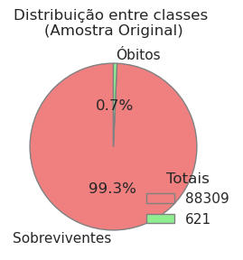

```python
df = pd.read_csv(folder + 'Mortes_infantil_RJ.csv')
print('\n-- Original Features --\n')
print(df.columns.tolist())

'''
df = pd.get_dummies(df, columns=['CODOCUPMAE'], prefix=['CODOCUPMAE'])
df = pd.get_dummies(df, columns=['APGAR1'], prefix=['APGAR1'])
df = pd.get_dummies(df, columns=['APGAR5'], prefix=['APGAR5'])
df = pd.get_dummies(df, columns=['CONSPRENAT'], prefix=['CONSPRENAT'])
df = pd.get_dummies(df, columns=['MESPRENAT'], prefix=['MESPRENAT'])
df = pd.get_dummies(df, columns=['SEMAGESTAC'], prefix=['SEMAGESTAC'])
'''

df = df.drop(['DIAS_DE_VIDA', 'CAUSABAS','DT_NASC','DT_OBITO','LINKAGE_QTDFILMORTANT'], axis=1).copy()

print('Dimensões', df.shape)
print('\n-- New Features Set --\n')
print(df.columns.tolist())
print('\n')
plot_donut_chart(df, '\n(Amostra Original)')
```

# 1) Divisão do conjunto de dados

## 1.1) Divisão de conjunto de dados em Validação, Treino e Teste

O conjunto de dados possui um total 88.930 registros, sendo 88.309 da classe 0 (sobreviventes) e 621 da classe 1 (óbitos neonatais), o que significa que estamos lidando com um problema que apresenta um conjunto de dados fortemente desbalanceado entre as classes.

Para divisão do conjunto de adotada a seguinte estratégia: do conjunto inicial 20% dos dados são separados para validação final; os 80% restantes, são divididos entre dados de treino e dados de teste na proporção 80% para treino e 20% para teste. As colunas 'DIAS_DE_VIDA', 'CAUSABAS', 'DT_NASC' e 'DT_OBITO' são removidas do conjunto de dados para os experimentos desta seção. A vairável 'CAUSABAS' será avaliada individualmente em experimentos posteriores, pois sua inclusão iria superajustar o modelo, uma vez que apenas os registros de mortes possuem esta informação. Com isso o conjunto de dados é particionado em três subconjuntos distintos: um conjunto de validação (X_val, y_val), um conjunto de treinamento (X_train, y_train) e um conjunto de teste (X_test, y_test). A divisão é realizada por meio da função 'train_test_split', incorporando um tamanho de teste de 20% e um estado aleatório fixo para garantir a reprodutibilidade.

Subconjunto, sobreviventes, óbitos neonatais Validação, 17671, 115 Treino, 56508, 407 Teste, 14130, 99

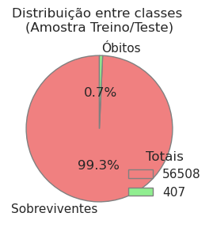

|  | 0 | 1 | 2 |
| --- | --- | --- | --- |
|  | Validação | Treino | Teste |
| sobreviventes | 17671 | 56508 | 14130 |
| óbitos neonatais | 115 | 407 | 99 |

```python
X = df.drop(columns=['OBITO_NEONATAL']).copy()
y = df['OBITO_NEONATAL'].copy()

# Plot KDEs
X = X.replace(-1,1e-9)

# Separação de 20% do conjunto de dados inicial para validação final
X_80, X_val, y_80, y_val = train_test_split(X, y, test_size=0.20, random_state=42)

# Separação do conjunto de dados em dados de treinamento e teste em proporção 80/20
X_train, X_test, y_train, y_test = train_test_split(X_80, y_80, test_size=0.20, random_state=42)

data = {'': ['Validação', 'Treino', 'Teste'],
        'sobreviventes': [y_val.value_counts()[0], y_train.value_counts()[0], y_test.value_counts()[0]],
        'óbitos neonatais': [y_val.value_counts()[1], y_train.value_counts()[1], y_test.value_counts()[1]]}

plot_donut_chart(pd.concat([X_train, y_train], axis=1), '\n(Amostra Treino/Teste)')

pd.DataFrame(data).T.to_csv('dados_iniciais.csv', header=False)
pd.DataFrame(data).T
```

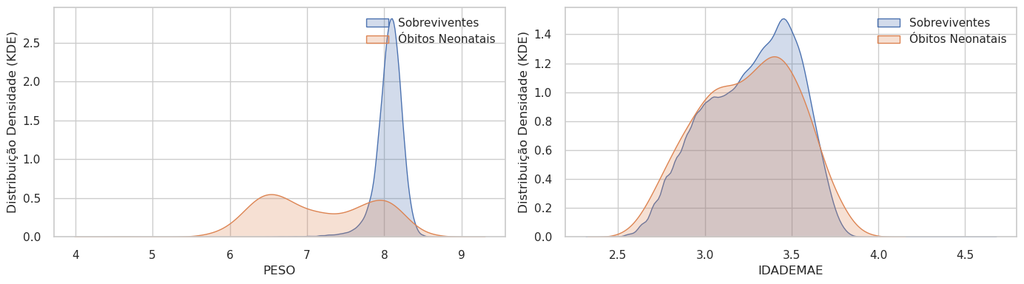

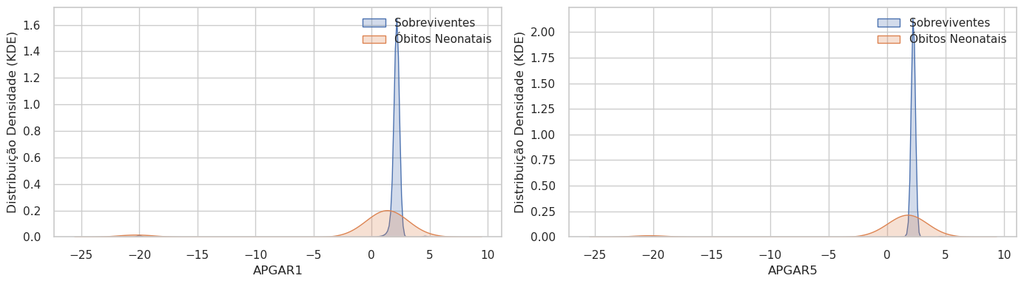

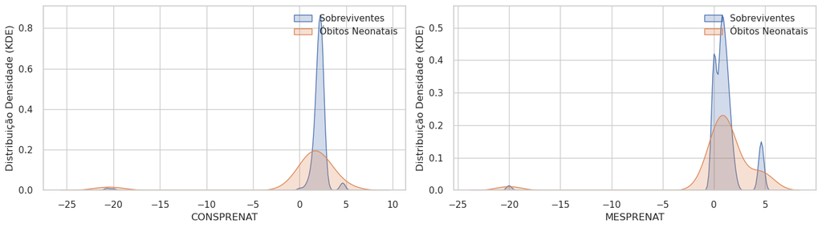

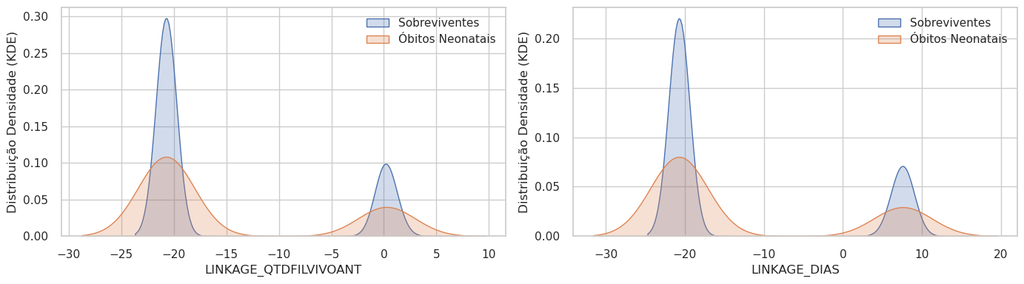

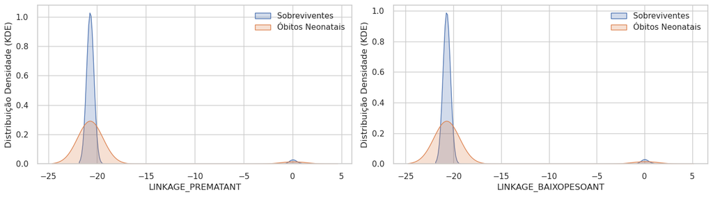

```python
# Plot KDEs
column_pairs = [('PESO', 'IDADEMAE'),
                ('APGAR1', 'APGAR5'),
                ('CONSPRENAT', 'MESPRENAT'),
                ('LINKAGE_QTDFILVIVOANT', 'LINKAGE_DIAS'),
                ('LINKAGE_PREMATANT', 'LINKAGE_BAIXOPESOANT')]

for column_pair in column_pairs:
    plot_weight_distribution(X_80, y_80, *column_pair)
```

#### KDE X_test

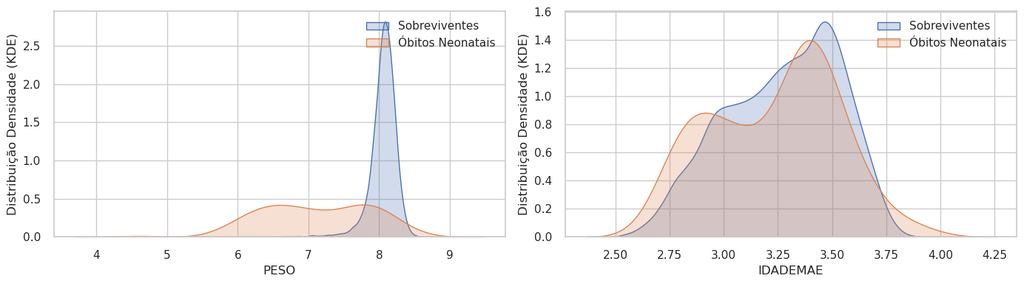

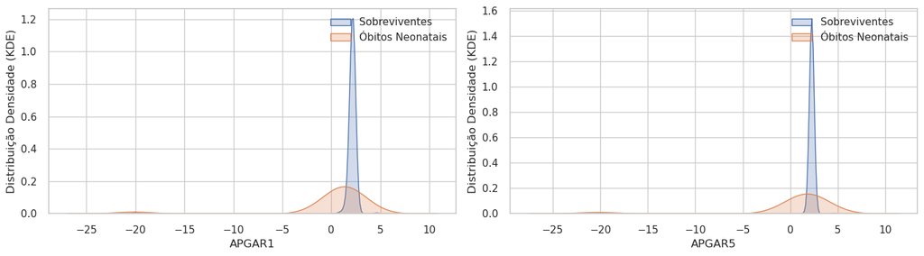

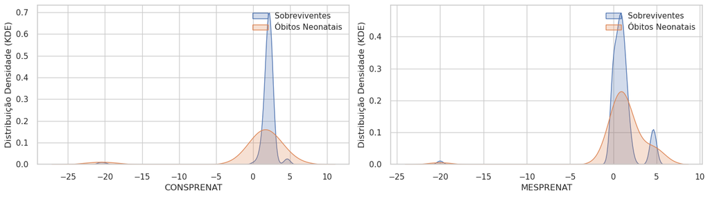

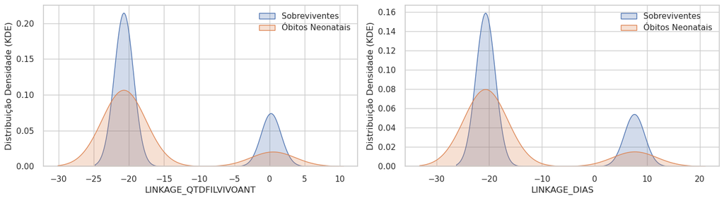

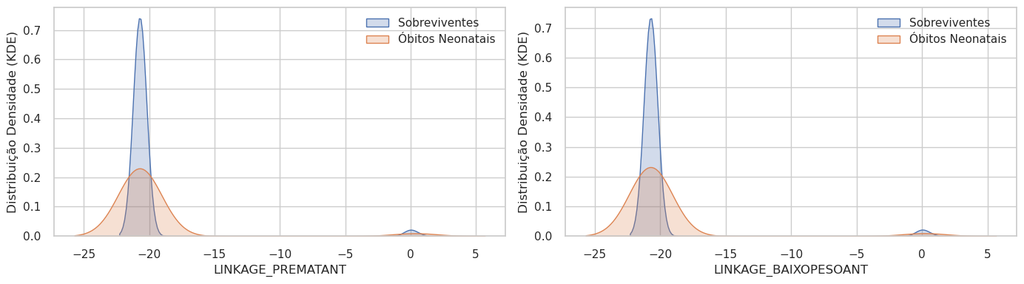

```python
# Plot KDEs
column_pairs = [('PESO', 'IDADEMAE'),
                ('APGAR1', 'APGAR5'),
                ('CONSPRENAT', 'MESPRENAT'),
                ('LINKAGE_QTDFILVIVOANT', 'LINKAGE_DIAS'),
                ('LINKAGE_PREMATANT', 'LINKAGE_BAIXOPESOANT')]

for column_pair in column_pairs:
    plot_weight_distribution(X_test, y_test, *column_pair)
```

#### KDE X_val

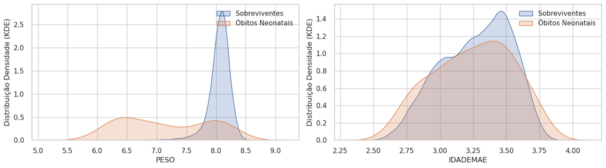

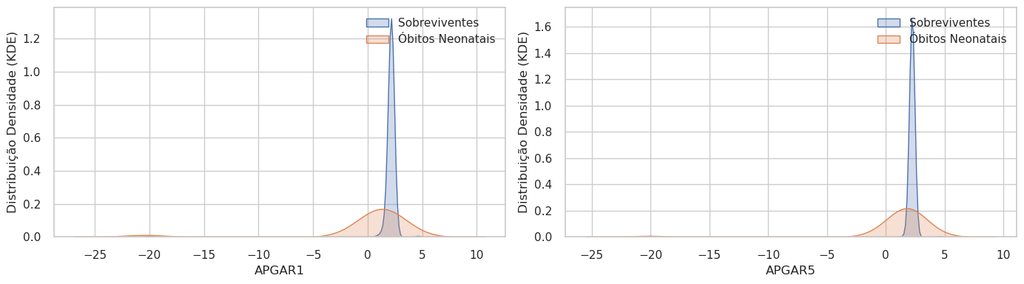

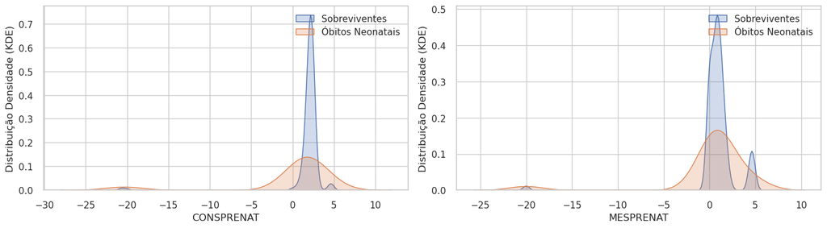

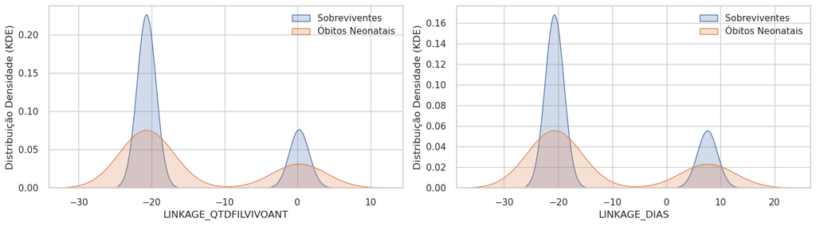

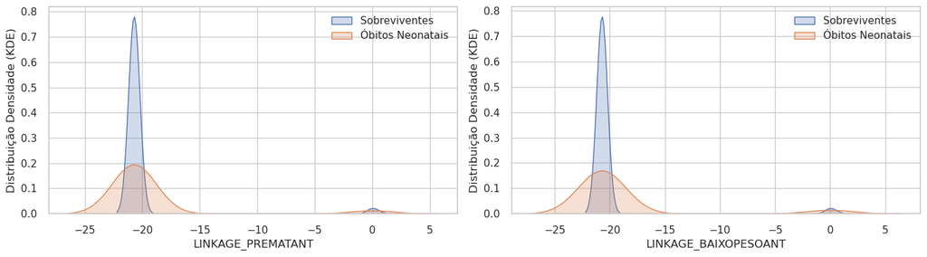

```python
# Plot KDEs
column_pairs = [('PESO', 'IDADEMAE'),
                ('APGAR1', 'APGAR5'),
                ('CONSPRENAT', 'MESPRENAT'),
                ('LINKAGE_QTDFILVIVOANT', 'LINKAGE_DIAS'),
                ('LINKAGE_PREMATANT', 'LINKAGE_BAIXOPESOANT')]

for column_pair in column_pairs:
    plot_weight_distribution(X_val, y_val, *column_pair)
```

“Nosso conjunto de dados foi categorizado em três partes distintas: treinamento, teste e validação final” Em relação ao conjunto de dados, procedeu-se à sua segmentação inicial, reservando-se 20% para o que será designado como validação final, termo também adotado por alguns pesquisadores para descrever esses dados como conjunto de teste. Essa parcela é essencial para realizar predições por meio dos modelos já treinados, atuando como um teste independente para validar a capacidade do modelo em realizar previsões precisas, uma vez que não foi utilizada durante o treinamento.

Os 80% restantes do conjunto de dados são dedicados ao treinamento dos modelos. Essa porção é subdividida em dois conjuntos distintos: treino, compreendendo 80% do total, e teste, composto pelos 20% restantes. Essa abordagem garante uma distribuição equitativa para a capacitação e avaliação dos modelos.

Assim, nosso conjunto de dados foi categorizado em três partes distintas: treinamento, teste e validação final, proporcionando uma estrutura robusta para o desenvolvimento e validação eficaz dos modelos propostos.

Adicionalmente, implementamos uma quarta segmentação visando a utilização de dados em abordagens de treinamento com classe única. Nesse contexto, os modelos foram treinados exclusivamente com a classe majoritária, considerando a classe minoritária como uma anomalia ou outlier.

Importante destacar que todas essas configurações foram realizadas utilizando apenas 80% da amostra inicial; os 20% reservados para a validação final não foram empregados em nenhuma das etapas.

## 1.2) Balanceamento "Undersample" por amostragem aleatória

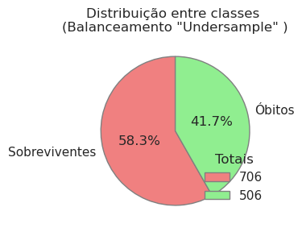

|  | 0 | 1 | 2 |
| --- | --- | --- | --- |
|  | Validação | Treino | Teste |
| sobreviventes | 17671 | 550 | 14130 |
| óbitos neonatais | 115 | 419 | 99 |

```python
df_80 = X_80.copy()
df_80['OBITO_NEONATAL'] = y_80.copy()

df_class_0 = df_80[df_80['OBITO_NEONATAL'] == 0].copy()
X_class_0 = df_class_0.drop(columns=['OBITO_NEONATAL']).copy()
y_class_0 = df_class_0['OBITO_NEONATAL'].copy()

df_class_1 = df_80[df_80['OBITO_NEONATAL'] == 1].copy()
X_class_1 = df_class_1.drop(columns=['OBITO_NEONATAL']).copy()
y_class_1 = df_class_1['OBITO_NEONATAL'].copy()

# Separação de ~1% da classe 0 pra balanceamento
X_bal, X_val_bal, y_bal, y_val_bal = train_test_split(X_class_0, y_class_0, test_size=0.99, random_state=42)

X_bal = pd.concat([X_bal, X_class_1])
y_bal = pd.concat([y_bal, y_class_1])

X_val_bal = pd.concat([X_val_bal, X_val])
y_val_bal = pd.concat([y_val_bal, y_val])

X_train_bal, X_test_bal, y_train_bal, y_test_bal = train_test_split(X_bal, y_bal, test_size=0.20, random_state=42)

data = {'': ['Validação', 'Treino', 'Teste'],
        'sobreviventes': [y_val.value_counts()[0], y_train_bal.value_counts()[0], y_test.value_counts()[0]],
        'óbitos neonatais': [y_val.value_counts()[1], y_train_bal.value_counts()[1], y_test.value_counts()[1]]}

plot_donut_chart(pd.concat([X_bal, y_bal], axis=1), '\n(Balanceamento "Undersample" )')

pd.DataFrame(data).T.to_csv('dados_undersample.csv', header=False)
pd.DataFrame(data).T
```

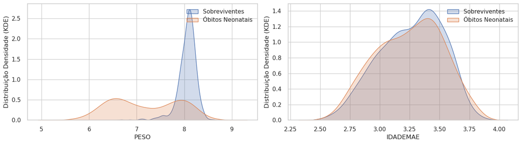

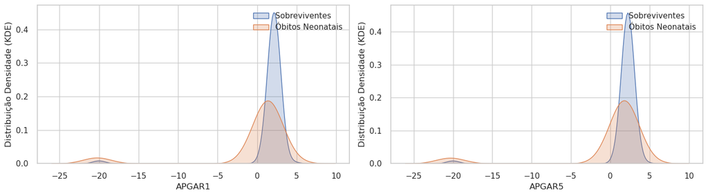

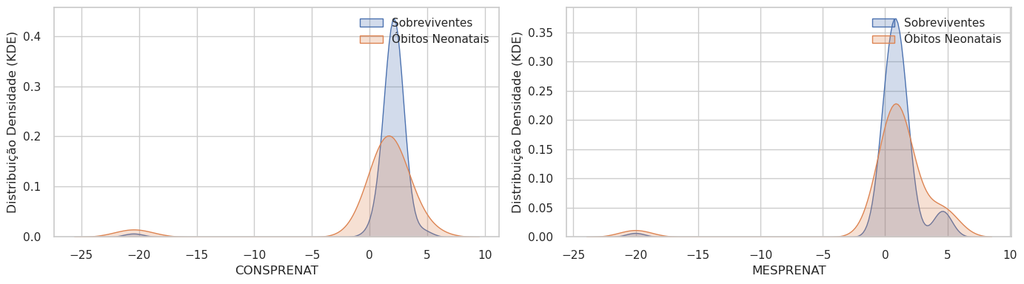

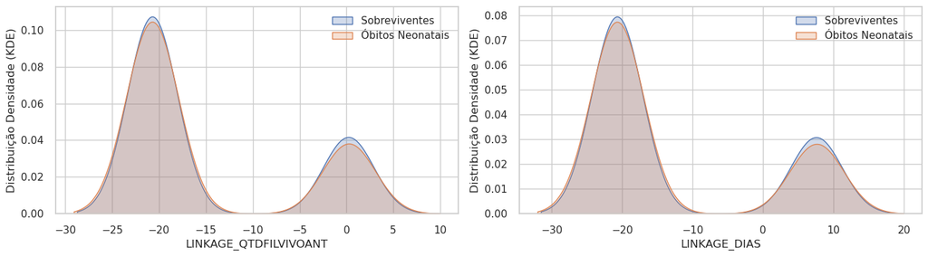

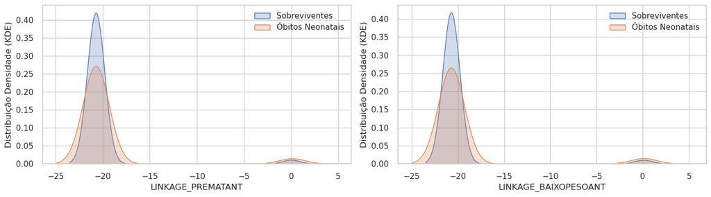

```python
# Plot KDEs
column_pairs = [('PESO', 'IDADEMAE'),
                ('APGAR1', 'APGAR5'),
                ('CONSPRENAT', 'MESPRENAT'),
                ('LINKAGE_QTDFILVIVOANT', 'LINKAGE_DIAS'),
                ('LINKAGE_PREMATANT', 'LINKAGE_BAIXOPESOANT')]

for column_pair in column_pairs:
    plot_weight_distribution(X_train_bal, y_train_bal, *column_pair)
```

## 1.3) Dados para abordagem de treinamento com classe única (SVM one class / Isolation Forest)

```python
X_train_one_class = pd.concat([X_train, y_train], axis=1)
X_train_one_class = X_train_one_class[X_train_one_class['OBITO_NEONATAL'] == 0].copy()
X_train_one_class = X_train_one_class.drop(columns=['OBITO_NEONATAL']).copy()

y_train_one_class = pd.Series(np.zeros(len(X_train_one_class), dtype=np.int64), name='OBITO_NEONATAL')

data = {'': ['Validação', 'Treino', 'Teste'],
        'sobreviventes': [y_val.value_counts()[0], len(y_train_one_class), y_test.value_counts()[0]],
        'óbitos neonatais': [y_val.value_counts()[1], 0, y_test.value_counts()[1]]}

pd.DataFrame(data).T.to_csv('dados_ONE_CLASS.csv', header=False)
pd.DataFrame(data).T
```

|  | 0 | 1 | 2 |
| --- | --- | --- | --- |
|  | Validação | Treino | Teste |
| sobreviventes | 17671 | 56508 | 14130 |
| óbitos neonatais | 115 | 0 | 99 |

## 1.4) Aplicação da técnica ENN para balanceamento "Undersample"

A técnica Edited Nearest Neighbours (ENN) é uma abordagem de subamostragem que visa identificar e remover instâncias potencialmente problemáticas de um conjunto de dados desequilibrado. Ao avaliar cada ponto de dados, o ENN examina a classe de seus vizinhos mais próximos, determinando se esses pontos são consistentes ou discordantes. Em particular, o ENN analisa a classe de cada instância e a compara com a classe de seus vizinhos mais próximos. Se a maioria dos vizinhos mais próximos de uma instância pertence a uma classe diferente da sua, ela é considerada potencialmente ruidosa e é removida do conjunto de dados.

Esta técnica utiliza a distância euclidiana ou outra métrica de distância para identificar vizinhos mais próximos. Ao remover instâncias inconsistentes, o ENN busca melhorar a qualidade do conjunto de dados de treinamento, removendo informações redundantes ou contraditórias que podem prejudicar o processo de aprendizado do modelo. No entanto, é essencial considerar o impacto da remoção de instâncias em conjunto com o equilíbrio entre as classes e a perda potencial de informações importantes.

Existem várias abordagens para lidar com conjuntos de dados desbalanceadas. Vamos aplicar duas estratégias para fins de comparação e análise. A primeira delas será aplicar uma técnica para reduzir o número de amostras da classe majoritária, conhecida como "undersample". Vamos aplicar duas estratégias, a primeira fazendo uma redução por amostragem, o que preserva a distribuição dos dados, porém podendo descartar amostras relevantes, e outra um método sistematico, que será a técnica de Edited Nearest Neighbours (ENN).

Está técnica apresenta vantagens substanciais em relação ao undersample aleatório em contextos de conjuntos de dados desequilibrados. Ao remover seletivamente exemplos que estão próximos das fronteiras das classes, o ENN preserva informações cruciais enquanto reduz o viés de classe. Isso resulta em uma distribuição de dados mais fiel à original, o que é crucial para manter a representatividade das classes e evitar a perda de informações críticas. Além disso, o ENN mitiga o impacto no desempenho do modelo ao manter uma quantidade significativa de dados, permitindo que o modelo aprenda relações mais precisas entre as classes. Esta abordagem oferece um equilíbrio entre a redução de dados e a preservação de informações valiosas, tornando-o uma ferramenta eficaz para lidar com o desbalanceamento de conjuntos de dados.

```python
file_path = folder + 'X_enn.pkl'

# Ler os arrays de arquivos pickle caso existam
if os.path.exists(file_path):
  with open(folder + 'X_enn.pkl', 'rb') as file:
      X_enn = pickle.load(file)

  with open(folder + 'y_enn.pkl', 'rb') as file:
      y_enn = pickle.load(file)

  # Indices para tratar registros exlcuídos como dados de testes
  with open(folder + 'enn_sample_indices.pkl', 'rb') as file:
      enn_sample_indices = pickle.load(file)
# Caso não existam, gerar e salvar
else:
  enn = EditedNearestNeighbours(sampling_strategy='auto', n_neighbors=500)
  X_enn, y_enn = enn.fit_resample(X_80, y_80)

  # Salvar os arrays em arquivos pickle
  with open(folder + 'X_enn.pkl', 'wb') as file:
      pickle.dump(X_enn, file)

  with open(folder + 'y_enn.pkl', 'wb') as file:
      pickle.dump(y_enn, file)

  # Indices para tratar registros exlcuídos como dados de testes
  with open(folder + 'enn_sample_indices.pkl', 'wb') as file:
      pickle.dump(enn.sample_indices_, file)
      enn_sample_indices = enn.sample_indices_
```

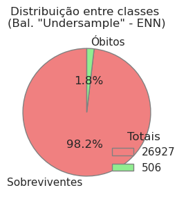

|  | 0 | 1 | 2 |
| --- | --- | --- | --- |
|  | Validação | Treino | Teste |
| sobreviventes | 17671 | 21545 | 14130 |
| óbitos neonatais | 115 | 401 | 99 |

```python
# Separação do conjunto de dados em dados de treinamento e teste em proporção 80/20
X_train_enn, X_test_enn, y_train_enn, y_test_enn = train_test_split(X_enn, y_enn, test_size=0.20, random_state=42)

X_val_enn = X_80.drop(index=X_80.index[enn_sample_indices]).copy()
y_val_enn = y_80.drop(index=y_80.index[enn_sample_indices]).copy()

X_val_enn = pd.concat([X_val_enn.copy(), X_val.copy()])
y_val_enn = pd.concat([y_val_enn.copy(), y_val.copy()])

data = {'': ['Validação', 'Treino', 'Teste'],
        'sobreviventes': [y_val.value_counts()[0], y_train_enn.value_counts()[0], y_test.value_counts()[0]],
        'óbitos neonatais': [y_val.value_counts()[1], y_train_enn.value_counts()[1], y_test.value_counts()[1]]}

plot_donut_chart(pd.concat([X_enn, y_enn], axis=1), '\n(Bal. "Undersample" - ENN)')

pd.DataFrame(data).T.to_csv('dados_undersample_ENN.csv', header=False)
pd.DataFrame(data).T
```

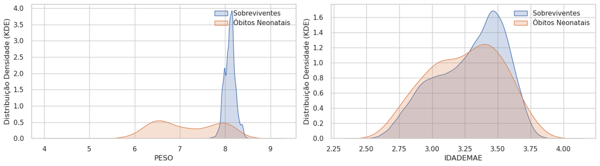

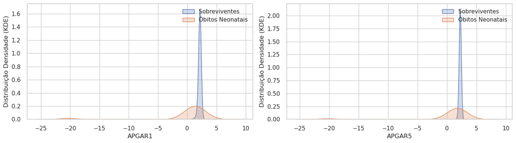

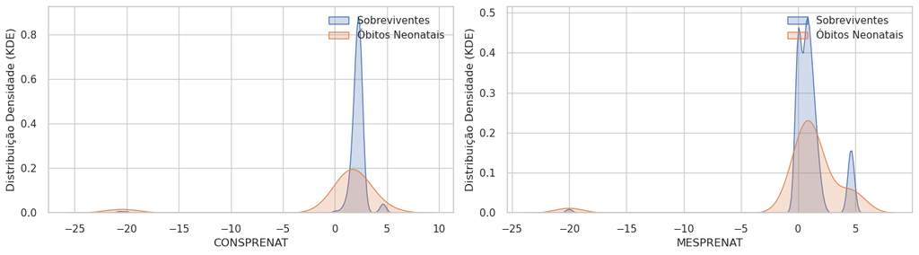

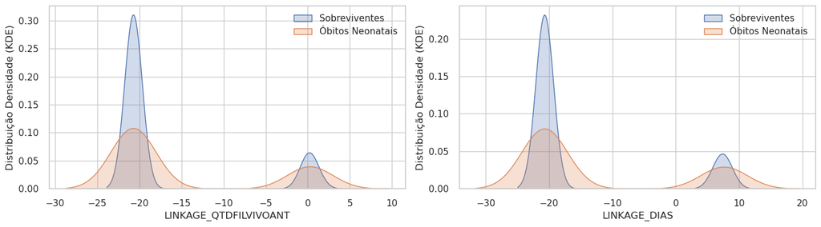

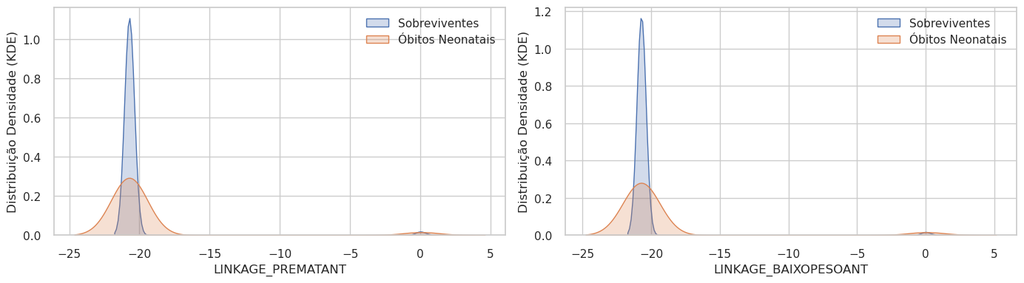

```python
# Plot KDEs TO

column_pairs = [('PESO', 'IDADEMAE'),
                ('APGAR1', 'APGAR5'),
                ('CONSPRENAT', 'MESPRENAT'),
                ('LINKAGE_QTDFILVIVOANT', 'LINKAGE_DIAS'),
                ('LINKAGE_PREMATANT', 'LINKAGE_BAIXOPESOANT')]

for column_pair in column_pairs:
    plot_weight_distribution(X_enn, y_enn, *column_pair)
```